# Session 4: GAM Practical II

Count data, spatial smooths and overdispersion

Oscar Rodriguez de Rivera | University of Exeter

```r
library(tidyverse)
library(mgcv)

theme_set(theme_minimal(base_size = 12))
```

# 1 Session overview

## 1.1 Aim

This practical connects three ideas from earlier sessions.

From **GLMs**, we use non-Gaussian responses and link functions.

From **GLMMs**, we remember that grouped observations can create extra variation.

From **GAMs**, we use smooth functions to model nonlinear covariate effects.

In this practical, we simulate ecological count data. The response is a count, and the expected number of individuals depends on:

- habitat type;
- sampling effort;
- spatial location;
- unobserved site-level variation.

The main question is:

> How can we fit a GAM for ecological count data when the response varies nonlinearly across space?

## 1.2 Learning outcomes

By the end of this practical, students should be able to:

- recognise count data and choose a suitable response distribution;
- include an offset for sampling effort;
- fit a Poisson GLM as a baseline model;
- fit a Poisson GAM with smooth covariate effects;
- fit a spatial GAM using a two-dimensional smooth;
- check for overdispersion;
- fit a negative-binomial GAM when Poisson assumptions are too restrictive;
- predict and interpret a spatial abundance surface;
- connect GAMs with GLMM-style random effects.

# 2 Ecological motivation

## 2.1 Count data in ecology

Many ecological responses are counts. For example:

- number of individuals detected at a site;
- number of seedlings in a quadrat;
- number of disease cases in a region;
- number of nests in a habitat patch;
- number of fire events in a grid cell.

Counts are non-negative integers, so a Gaussian model is usually not the best first choice.

A common starting point is the Poisson model.

## 2.2 The Poisson mean

For a Poisson model, the expected count is usually written as:

$$Y_i \sim \text{Poisson}(\lambda_i)$$

A log link is commonly used:

$$\log(\lambda_i) = \eta_i$$

This ensures that the expected count is always positive.

## 2.3 Why use an offset?

In ecological surveys, sampling effort often varies.

For example, one site may be surveyed for 30 minutes and another for 2 hours. If the second site has more individuals, this may partly reflect greater effort rather than higher abundance.

An offset adjusts the model for known differences in effort.

With an offset, the model is:

$$\log(\lambda_i) = \eta_i + \log(\text{effort}_i)$$

This means we are modelling the expected count while accounting for how much sampling effort was used.

# 3 Simulate ecological count data

## 3.1 Data-generating idea

Imagine that we surveyed species counts at locations across a landscape.

Counts depend on:

- the habitat type;
- the sampling effort;
- the spatial coordinates;
- unmeasured differences among sites.

The spatial pattern is not linear. There is a smooth region of higher expected abundance and a smooth region of lower expected abundance.

```r
set.seed(345)

n <- 800
n_sites <- 40

site_ids <- paste0("site_", seq_len(n_sites))
site_effects <- rnorm(n_sites, mean = 0, sd = 0.45)
names(site_effects) <- site_ids

ecology_counts <- tibble(
  site = factor(sample(site_ids, n, replace = TRUE)),
  x = runif(n),
  z = runif(n),
  habitat = factor(
    sample(
      c("grassland", "woodland", "wetland"),
      n,
      replace = TRUE
    )
  ),
  effort = runif(n, 0.5, 2)
) %>%
  mutate(
    habitat_effect = case_when(
      habitat == "grassland" ~ 0,
      habitat == "woodland" ~ 0.5,
      habitat == "wetland" ~ 0.9
    ),
    spatial_effect =
      1.2 * exp(-((x - 0.70)^2 + (z - 0.35)^2) / 0.035) -
      0.8 * exp(-((x - 0.25)^2 + (z - 0.75)^2) / 0.025),
    eta = -0.3 +
      habitat_effect +
      spatial_effect +
      log(effort) +
      site_effects[as.character(site)],
    count = rpois(n, lambda = exp(eta))
  ) %>%
  dplyr::select(site, x, z, habitat, effort, count)

dplyr::glimpse(ecology_counts)
```

```
## Rows: 800
## Columns: 6
## $ site    <fct> site_37, site_34, site_3, site_37, site_1, site_35, site_11, s…
## $ x       <dbl> 0.45487510, 0.64638826, 0.50381099, 0.03905619, 0.15566427, 0.…
## $ z       <dbl> 0.41890058, 0.89078374, 0.98722377, 0.69446082, 0.47442171, 0.…
## $ habitat <fct> grassland, wetland, wetland, woodland, woodland, grassland, gr…
## $ effort  <dbl> 1.8754898, 0.8828413, 1.4995330, 1.2470249, 1.1088876, 1.35388…
## $ count   <int> 2, 4, 3, 2, 1, 2, 2, 1, 0, 3, 2, 0, 1, 3, 5, 2, 0, 4, 3, 0, 4,…
```

## 3.2 Inspect the response

```r
ecology_counts %>%
  summarise(
    n = n(),
    min_count = min(count),
    mean_count = mean(count),
    median_count = median(count),
    max_count = max(count),
    proportion_zeros = mean(count == 0)
  )
```

| n | min_count | mean_count | median_count | max_count | proportion_zeros |
| --- | --- | --- | --- | --- | --- |
| 800 | 0 | 2.02875 | 1 | 22 | 0.24125 |

Counts are usually skewed and often contain zeros. This is one reason why a Poisson or negative-binomial model is more appropriate than a Gaussian model.

# 4 Exploratory plots

## 4.1 Counts across space

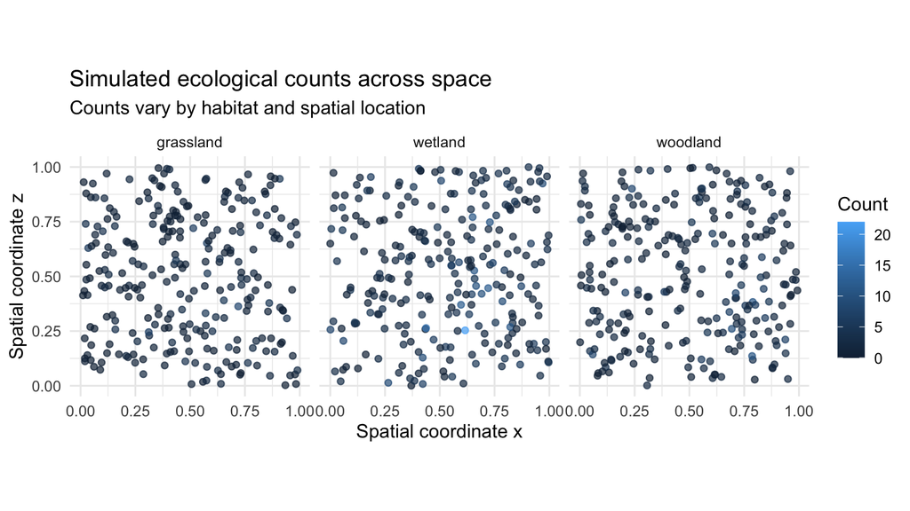

```r
ggplot(ecology_counts, aes(x = x, y = z, colour = count)) +
  geom_point(alpha = 0.7) +
  facet_wrap(~ habitat) +
  coord_equal() +
  labs(
    x = "Spatial coordinate x",
    y = "Spatial coordinate z",
    colour = "Count",
    title = "Simulated ecological counts across space",
    subtitle = "Counts vary by habitat and spatial location"
  )
```

## 4.2 Counts by habitat

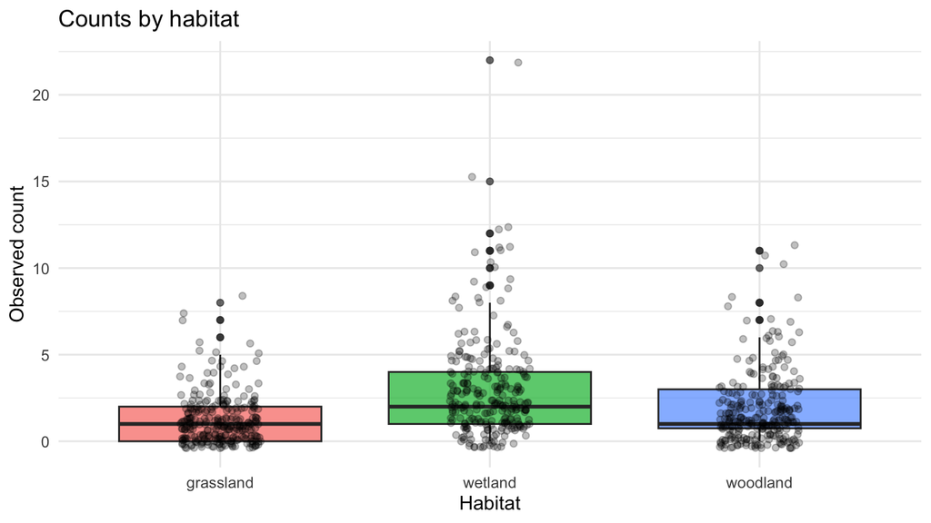

```r
ggplot(ecology_counts, aes(x = habitat, y = count, fill = habitat)) +
  geom_boxplot(alpha = 0.7) +
  geom_jitter(width = 0.15, alpha = 0.25) +
  guides(fill = "none") +
  labs(
    title = "Counts by habitat",
    x = "Habitat",
    y = "Observed count"
  )
```

## 4.3 Sampling effort

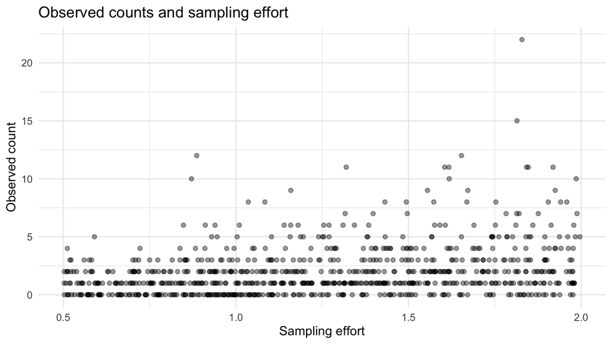

```r
ggplot(ecology_counts, aes(x = effort, y = count)) +
  geom_point(alpha = 0.4) +
  labs(
    title = "Observed counts and sampling effort",
    x = "Sampling effort",
    y = "Observed count"
  )
```

Effort affects the expected count. Higher effort gives more opportunity to detect individuals.

This is why we include `offset(log(effort))` in the model.

# 5 Baseline Poisson GLM

## 5.1 Fit a simple Poisson GLM

We first fit a baseline Poisson GLM.

This model includes habitat and linear effects of the spatial coordinates.

```r
glm_pois <- glm(
  count ~ habitat + x + z + offset(log(effort)),
  data = ecology_counts,
  family = poisson()
)

summary(glm_pois)
```

```
##
## Call:
## glm(formula = count ~ habitat + x + z + offset(log(effort)),
##     family = poisson(), data = ecology_counts)
##
## Coefficients:
##                 Estimate Std. Error z value Pr(>|z|)
## (Intercept)     -0.08212    0.08229  -0.998    0.318
## habitatwetland   0.87600    0.06544  13.385  < 2e-16 ***
## habitatwoodland  0.45088    0.07065   6.382 1.74e-10 ***
## x                0.45414    0.08765   5.181 2.20e-07 ***
## z               -0.34958    0.08762  -3.990 6.62e-05 ***
## ---
## Signif. codes:  0 '***' 0.001 '**' 0.01 '*' 0.05 '.' 0.1 ' ' 1
##
## (Dispersion parameter for poisson family taken to be 1)
##
##     Null deviance: 1585.1  on 799  degrees of freedom
## Residual deviance: 1337.8  on 795  degrees of freedom
## AIC: 2964.5
##
## Number of Fisher Scoring iterations: 5
```

## 5.2 Interpretation

This model assumes that the effect of `x` is linear and the effect of `z` is linear.

That may be too simple because the true spatial pattern is smooth and two-dimensional.

A linear model can only represent a flat spatial gradient. It cannot represent a hotspot or coldspot unless the pattern happens to be linear.

# 6 Poisson GAM with separate smooths

## 6.1 Fit separate smooths for x and z

A first GAM extension is to replace the linear terms for `x` and `z` with smooth terms.

```r
gam_pois_separate <- mgcv::gam(
  count ~ habitat +
    s(x, k = 10) +
    s(z, k = 10) +
    offset(log(effort)),
  data = ecology_counts,
  family = poisson(link = "log"),
  method = "REML"
)

summary(gam_pois_separate)
```

```
##
## Family: poisson
## Link function: log
##
## Formula:
## count ~ habitat + s(x, k = 10) + s(z, k = 10) + offset(log(effort))
##
## Parametric coefficients:
##                 Estimate Std. Error z value Pr(>|z|)
## (Intercept)     -0.05620    0.05519  -1.018    0.309
## habitatwetland   0.86786    0.06562  13.225  < 2e-16 ***
## habitatwoodland  0.44799    0.07094   6.315  2.7e-10 ***
## ---
## Signif. codes:  0 '***' 0.001 '**' 0.01 '*' 0.05 '.' 0.1 ' ' 1
##
## Approximate significance of smooth terms:
##        edf Ref.df Chi.sq p-value
## s(x) 5.227  6.344  95.29  <2e-16 ***
## s(z) 4.231  5.215  42.84  <2e-16 ***
## ---
## Signif. codes:  0 '***' 0.001 '**' 0.01 '*' 0.05 '.' 0.1 ' ' 1
##
## R-sq.(adj) =  0.301   Deviance explained = 22.2%
## -REML = 1450.4  Scale est. = 1         n = 800
```

## 6.2 Interpretation

This model allows the effect of `x` to be nonlinear and the effect of `z` to be nonlinear.

However, the two smooths are still additive:

$$\log(\lambda_i) = \beta_0 + f_1(x_i) + f_2(z_i) + \text{habitat effect}
+ \log(\text{effort}_i)$$

This means the effect of `x` does not depend on `z`, and the effect of `z` does not depend on `x`.

For a spatial surface, this may still be too simple.

# 7 Spatial GAM with a two-dimensional smooth

## 7.1 Why use a two-dimensional smooth?

A spatial process often depends on the combination of two coordinates.

For example, abundance may be highest near a particular location in the landscape.

That cannot always be described as a separate smooth of `x` plus a separate smooth of `z`.

A two-dimensional smooth allows the response to vary across the spatial surface.

## 7.2 Fit a tensor-product spatial smooth

```r
gam_pois_spatial <- mgcv::gam(
  count ~ habitat +
    te(x, z, k = c(12, 12)) +
    offset(log(effort)),
  data = ecology_counts,
  family = poisson(link = "log"),
  method = "REML"
)

summary(gam_pois_spatial)
```

```
##
## Family: poisson
## Link function: log
##
## Formula:
## count ~ habitat + te(x, z, k = c(12, 12)) + offset(log(effort))
##
## Parametric coefficients:
##                 Estimate Std. Error z value Pr(>|z|)
## (Intercept)     -0.06343    0.05576  -1.138    0.255
## habitatwetland   0.85267    0.06694  12.738  < 2e-16 ***
## habitatwoodland  0.44884    0.07206   6.229 4.71e-10 ***
## ---
## Signif. codes:  0 '***' 0.001 '**' 0.01 '*' 0.05 '.' 0.1 ' ' 1
##
## Approximate significance of smooth terms:
##           edf Ref.df Chi.sq p-value
## te(x,z) 33.12   45.5  215.7  <2e-16 ***
## ---
## Signif. codes:  0 '***' 0.001 '**' 0.01 '*' 0.05 '.' 0.1 ' ' 1
##
## R-sq.(adj) =  0.342   Deviance explained =   28%
## -REML = 1431.5  Scale est. = 1         n = 800
```

## 7.3 Interpretation

The term `te(x, z)` fits a smooth surface over the two spatial coordinates.

This allows the expected count to change flexibly across space.

The model is:

$$\log(\lambda_i) =
\beta_0 +
\text{habitat effect}_i +
f(x_i, z_i) +
\log(\text{effort}_i)$$

where (f(x_i, z_i)) is a two-dimensional smooth spatial effect.

# 8 Model comparison

## 8.1 Compare Poisson models

```r
AIC(
  glm_pois,
  gam_pois_separate,
  gam_pois_spatial
)
```

|  | df | AIC |
| --- | --- | --- |
| glm_pois | 5.00000 | 2964.506 |
| gam_pois_separate | 13.17542 | 2876.823 |
| gam_pois_spatial | 38.89791 | 2835.637 |

## 8.2 Interpretation

AIC compares models fitted to the same response.

Lower AIC suggests a better balance between model fit and complexity.

If the spatial GAM has a much lower AIC than the GLM, this suggests that the nonlinear spatial surface improves the model.

However, AIC is not the only criterion. We should also inspect residuals, overdispersion and whether the model makes ecological sense.

# 9 Checking overdispersion

## 9.1 What is overdispersion?

For a Poisson model, the mean and variance are assumed to be equal:

$$E(Y_i) = Var(Y_i) = \lambda_i$$

In ecological count data, the variance is often larger than the mean. This is called **overdispersion**.

Overdispersion can happen because of:

- unmeasured environmental variation;
- clustering of individuals;
- repeated observations within sites;
- missing covariates;
- zero inflation;
- individual heterogeneity.

If overdispersion is present, a Poisson model can underestimate uncertainty.

## 9.2 Pearson residual overdispersion check

A rough overdispersion check is:

$$\frac{\sum r_i^2}{df}$$

where (r_i) are Pearson residuals and (df) is the residual degrees of freedom.

Values close to 1 are consistent with the Poisson assumption. Values much larger than 1 suggest overdispersion.

```r
check_overdispersion <- function(model) {
  sum(residuals(model, type = "pearson")^2) / df.residual(model)
}

overdispersion_table <- tibble(
  model = c(
    "Poisson GLM",
    "Poisson GAM with separate smooths",
    "Spatial Poisson GAM"
  ),
  overdispersion = c(
    check_overdispersion(glm_pois),
    check_overdispersion(gam_pois_separate),
    check_overdispersion(gam_pois_spatial)
  )
)

overdispersion_table
```

| model | overdispersion |
| --- | --- |
| Poisson GLM | 1.730512 |
| Poisson GAM with separate smooths | 1.568855 |
| Spatial Poisson GAM | 1.440367 |

## 9.3 Interpretation

If overdispersion is much larger than 1, the Poisson model is too restrictive.

A spatial smooth may reduce overdispersion if spatial structure was causing extra variation.

However, if overdispersion remains after modelling spatial structure, a negative-binomial model may be more appropriate.

# 10 Negative-binomial GAM

## 10.1 Why use a negative-binomial model?

The negative-binomial distribution is useful for overdispersed count data.

It allows the variance to be larger than the mean.

This makes it a common alternative to the Poisson model in ecology.

## 10.2 Fit a negative-binomial spatial GAM

```r
gam_nb_spatial <- mgcv::gam(
  count ~ habitat +
    te(x, z, k = c(12, 12)) +
    offset(log(effort)),
  data = ecology_counts,
  family = mgcv::nb(link = "log"),
  method = "REML"
)

summary(gam_nb_spatial)
```

```
##
## Family: Negative Binomial(4.443)
## Link function: log
##
## Formula:
## count ~ habitat + te(x, z, k = c(12, 12)) + offset(log(effort))
##
## Parametric coefficients:
##                 Estimate Std. Error z value Pr(>|z|)
## (Intercept)     -0.05234    0.06358  -0.823     0.41
## habitatwetland   0.85161    0.07986  10.664  < 2e-16 ***
## habitatwoodland  0.43295    0.08445   5.127 2.95e-07 ***
## ---
## Signif. codes:  0 '***' 0.001 '**' 0.01 '*' 0.05 '.' 0.1 ' ' 1
##
## Approximate significance of smooth terms:
##           edf Ref.df Chi.sq p-value
## te(x,z) 21.59  29.92  105.3  <2e-16 ***
## ---
## Signif. codes:  0 '***' 0.001 '**' 0.01 '*' 0.05 '.' 0.1 ' ' 1
##
## R-sq.(adj) =  0.324   Deviance explained = 24.1%
## -REML = 1394.4  Scale est. = 1         n = 800
```

## 10.3 Compare Poisson and negative-binomial spatial GAMs

```r
AIC(
  gam_pois_spatial,
  gam_nb_spatial
)
```

|  | df | AIC |
| --- | --- | --- |
| gam_pois_spatial | 38.89791 | 2835.637 |
| gam_nb_spatial | 28.06113 | 2780.506 |

```r
tibble(
  model = c(
    "Spatial Poisson GAM",
    "Spatial negative-binomial GAM"
  ),
  overdispersion = c(
    check_overdispersion(gam_pois_spatial),
    check_overdispersion(gam_nb_spatial)
  )
)
```

| model | overdispersion |
| --- | --- |
| Spatial Poisson GAM | 1.440367 |
| Spatial negative-binomial GAM | 1.002660 |

## 10.4 Interpretation

If the negative-binomial GAM has lower AIC and a more reasonable overdispersion value, it is usually preferable.

The negative-binomial model acknowledges that ecological counts may be more variable than the Poisson distribution allows.

# 11 Predicting a spatial surface

## 11.1 Prediction grid

We now use the fitted negative-binomial GAM to predict expected counts across the landscape.

We predict expected counts for one unit of effort in woodland habitat.

```r
pred_grid <- tidyr::expand_grid(
  x = seq(0, 1, length.out = 80),
  z = seq(0, 1, length.out = 80)
) %>%
  dplyr::mutate(
    habitat = factor("woodland", levels = levels(ecology_counts$habitat)),
    effort = 1
  )

pred_grid <- pred_grid %>%
  dplyr::mutate(
    predicted_count = predict(
      gam_nb_spatial,
      newdata = pred_grid,
      type = "response"
    )
  )

dplyr::glimpse(pred_grid)
```

```
## Rows: 6,400
## Columns: 5
## $ x               <dbl> 0, 0, 0, 0, 0, 0, 0, 0, 0, 0, 0, 0, 0, 0, 0, 0, 0, 0, …
## $ z               <dbl> 0.00000000, 0.01265823, 0.02531646, 0.03797468, 0.0506…
## $ habitat         <fct> woodland, woodland, woodland, woodland, woodland, wood…
## $ effort          <dbl> 1, 1, 1, 1, 1, 1, 1, 1, 1, 1, 1, 1, 1, 1, 1, 1, 1, 1, …
## $ predicted_count <dbl[1d]> <array[26]>
```

## 11.2 Plot the predicted spatial surface

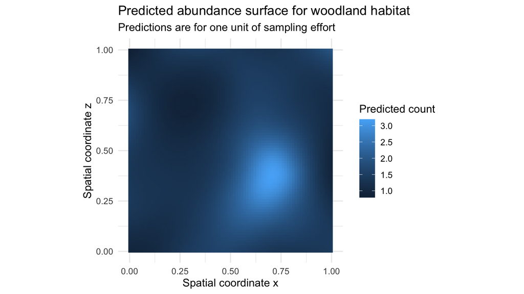

```r
ggplot(pred_grid, aes(x = x, y = z, fill = predicted_count)) +
  geom_raster() +
  coord_equal() +
  labs(
    x = "Spatial coordinate x",
    y = "Spatial coordinate z",
    fill = "Predicted count",
    title = "Predicted abundance surface for woodland habitat",
    subtitle = "Predictions are for one unit of sampling effort"
  )
```

## 11.3 Interpretation

The map shows where the model predicts higher or lower expected counts.

Because effort is fixed at 1, differences in the map are not caused by sampling effort.

Because habitat is fixed to woodland, the map shows the spatial pattern for woodland habitat only.

This is a useful way to interpret the fitted spatial smooth.

# 12 Model checking

## 12.1 Check the negative-binomial GAM

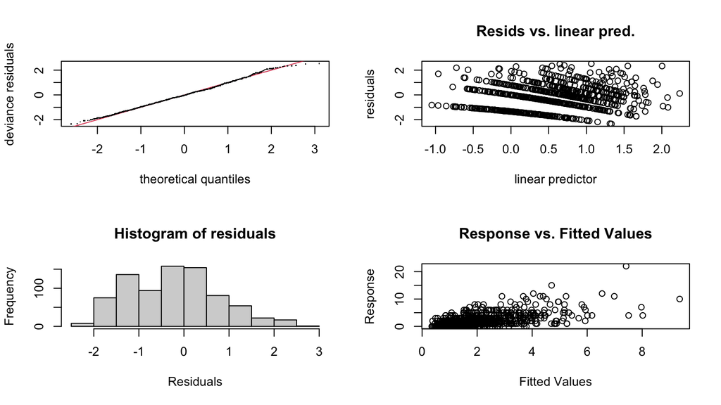

```
##
## Method: REML   Optimizer: outer newton
## full convergence after 5 iterations.
## Gradient range [-8.185796e-08,-3.627028e-10]
## (score 1394.44 & scale 1).
## Hessian positive definite, eigenvalue range [1.400154,35.72997].
## Model rank =  146 / 146
##
## Basis dimension (k) checking results. Low p-value (k-index<1) may
## indicate that k is too low, especially if edf is close to k'.
##
##            k'   edf k-index p-value
## te(x,z) 143.0  21.6    0.92    0.17
```

```r
mgcv::gam.check(gam_nb_spatial)
```

## 12.2 Interpretation

The diagnostics help assess whether the model is adequate.

Look for:

- residual patterns;
- influential outliers;
- a low `k-index`;
- evidence that the basis dimension may be too small;
- remaining structure that the model has not captured.

Diagnostics should be interpreted together with ecological understanding.

# 13 Optional extension: grouped data

## 13.1 Site-level variation

The simulation included a site effect, but the main models above did not include site as a random effect.

This means there may still be grouped variation among sites.

In `mgcv`, random effects can be included using a random-effect smooth, such as:

```r
gam_nb_site <- mgcv::gam(
  count ~ habitat +
    te(x, z, k = c(12, 12)) +
    s(site, bs = "re") +
    offset(log(effort)),
  data = ecology_counts,
  family = mgcv::nb(link = "log"),
  method = "REML"
)
```

This connects directly to the GLMM session.

The term `s(site, bs = "re")` acts like a random intercept for site.

## 13.2 Why might this matter?

If observations from the same site are more similar than observations from different sites, ignoring site effects can underestimate uncertainty.

A model with a site random effect can account for unexplained site-to-site variation.

# 14 Exercise

## 14.1 Questions

1. Repeat the spatial prediction for `grassland` and `wetland`.
2. Fit a model without the offset. How does interpretation change?
3. Compare the Poisson and negative-binomial versions using AIC and overdispersion.
4. Write a short ecological interpretation of the spatial surface.

# 15 Exercise solution

## 15.1 1. Repeat the spatial prediction for `grassland` and `wetland`

```r
#The spatial pattern is similar across habitats because the same spatial smooth is used for all habitats. However, the overall predicted counts differ because the model includes a habitat effect.

#In this simulated dataset, wetland is expected to have higher counts than woodland, and woodland is expected to have higher counts than grassland.
```

## 15.2 2. Fit a model without the offset

```r
#The model without the offset does not adjust for sampling effort.

#This changes the interpretation. With the offset, we are modelling expected counts for a given amount of effort. Without the offset, the model treats differences in observed counts as if they were only due to habitat and spatial location.

#This is problematic if effort varies among observations. Higher counts may simply reflect greater sampling effort rather than higher abundance.

#So, for these data, the model with the offset is preferable because survey effort is part of the data-generating process.
```

## 15.3 3. Compare the Poisson and negative-binomial versions

```r
#The Poisson model assumes that the mean and variance of the counts are equal. Ecological count data often have more variation than this.

#If the overdispersion value for the Poisson model is clearly larger than 1, this suggests extra-Poisson variation.

#The negative-binomial GAM is usually preferred if it has lower AIC and a more reasonable overdispersion value. It allows the variance to be larger than the mean, which is often more realistic for ecological count data.
```

## 15.4 4. Short ecological interpretation of the spatial surface

```r
#A suitable interpretation is:

#Predicted counts vary across the landscape in a smooth spatial pattern, with a hotspot of higher expected abundance in one region and lower expected abundance elsewhere. After accounting for sampling effort, wetland has the highest expected counts, followed by woodland and grassland. This suggests that both habitat type and spatial location are associated with variation in abundance.

#A more concise version is:

#The model predicts higher abundance in wetland habitats and in particular parts of the landscape, suggesting that abundance is structured by both habitat and spatial location.
```

## 15.5 Overall answer

```r
#The preferred model is the negative-binomial spatial GAM with the effort offset:
```

[output not shown]

```r
#This model is preferred because it:

#- uses an appropriate count distribution;
#- accounts for sampling effort using an offset;
#- allows a nonlinear two-dimensional spatial pattern;
#- handles overdispersion better than the Poisson version;
#- gives interpretable spatial predictions.
```

# 16 Summary

In this practical, we fitted GAMs for ecological count data.

Key points:

- count data are often modelled using Poisson or negative-binomial models;
- a log link ensures positive expected counts;
- offsets adjust for known differences in sampling effort;
- separate smooths of `x` and `z` may be too simple for spatial data;
- `te(x, z)` can model a two-dimensional spatial surface;
- overdispersion is common in ecological counts;
- negative-binomial GAMs can handle extra-Poisson variation;
- spatial prediction grids help visualise fitted abundance surfaces;
- random-effect smooths can connect GAMs back to GLMM-style grouped data.

# 17 Link to the SEM documents

GAMs are excellent for flexible prediction and nonlinear effects.

SEM asks a different question:

> How do variables sit together in a hypothesised causal system?

We now move from flexible prediction to pathway thinking.